# Groundhog Day

## Groundhog Day Prediction Analysis

##### This is what happens when you are avoiding schoolwork on Groundhog's Day

```python
import pandas as pd
import xlwings as xw
```

```python
data_sheet = xw.Book('groundhog_day.xlsx').sheets[0]
```

I imported the average 2-month temperatures in Punxsutawney, PA (most famous Groundhog's Day event) going back to 1901 from https://www.ncdc.noaa.gov/. These temperatures are given as the temperature difference compared to the average temperature between 1980-2018 for that same area.

I also determined whether or not the groundhog saw his shadow from Punxsutawney's website http://www.groundhog.org.

```python
df = pd.DataFrame(data_sheet.range('A1').expand().value)
df.columns = df.iloc[0,:]
df = df[1:-1]
df
```

|  | Year | Avg 2mo Temp Anomaly | See Shadow? |
| --- | --- | --- | --- |
| 1 | 1901 | -2.3 | Yes |
| 2 | 1902 | -1.81 | No |
| 3 | 1903 | -0.3 | Yes |
| 4 | 1904 | -4.62 | Yes |
| 5 | 1905 | -3.76 | Yes |
| 6 | 1906 | 0.5 | Yes |
| 7 | 1907 | -2.37 | Yes |
| 8 | 1908 | -1.79 | Yes |
| 9 | 1909 | 1.22 | Yes |
| 10 | 1910 | -1.48 | Yes |
| 11 | 1911 | 0.04 | Yes |
| 12 | 1912 | -3.46 | Yes |
| 13 | 1913 | 0.9 | Yes |
| 14 | 1914 | -2.12 | Yes |
| 15 | 1915 | 0.45 | Yes |
| 16 | 1916 | -0.36 | Yes |
| 17 | 1917 | -2.04 | Yes |
| 18 | 1918 | -3.58 | Yes |
| 19 | 1919 | 0.89 | Yes |
| 20 | 1920 | -3.79 | Yes |
| 21 | 1921 | 0.71 | Yes |
| 22 | 1922 | -1.04 | Yes |
| 23 | 1923 | -2.39 | Yes |
| 24 | 1924 | -1.53 | Yes |
| 25 | 1925 | -0.32 | Yes |
| 26 | 1926 | -1.13 | Yes |
| 27 | 1927 | -0.17 | Yes |
| 28 | 1928 | -0.34 | Yes |
| 29 | 1929 | -0.82 | Yes |
| 30 | 1930 | 0.13 | Yes |
| ... | ... | ... | ... |
| 89 | 1989 | 0.49 | Yes |
| 90 | 1990 | 2.51 | No |
| 91 | 1991 | 1.02 | Yes |
| 92 | 1992 | 0.65 | Yes |
| 93 | 1993 | -0.81 | Yes |
| 94 | 1994 | -3.47 | Yes |
| 95 | 1995 | 0.14 | No |
| 96 | 1996 | -1.13 | Yes |
| 97 | 1997 | 0.5 | No |
| 98 | 1998 | 2.94 | Yes |
| 99 | 1999 | 0.61 | No |
| 100 | 2000 | 0.36 | Yes |
| 101 | 2001 | 0.55 | Yes |
| 102 | 2002 | 3.06 | Yes |
| 103 | 2003 | -2.49 | Yes |
| 104 | 2004 | -2.08 | Yes |
| 105 | 2005 | -0.28 | Yes |
| 106 | 2006 | 2.4 | Yes |
| 107 | 2007 | -0.4 | No |
| 108 | 2008 | 0.85 | Yes |
| 109 | 2009 | -1.23 | Yes |
| 110 | 2010 | 0.06 | Yes |
| 111 | 2011 | -0.98 | No |
| 112 | 2012 | 2.56 | Yes |
| 113 | 2013 | 0.76 | No |
| 114 | 2014 | -2.45 | Yes |
| 115 | 2015 | -3.97 | Yes |
| 116 | 2016 | 1.3 | No |
| 117 | 2017 | 3.26 | Yes |
| 118 | 2018 | 0.83 | Yes |

118 rows × 3 columns

```python
import matplotlib.pyplot as plt
import seaborn as sns
sns.set_style('darkgrid')
```

```python
df['Year'] = df['Year'].astype(float)
```

Below is a scatterplot of all of the temperatures going back to 1900. Right away, we see that there is an obvioius trendline and that temperatures have risen on average ~1.5°C. I have included the trendline with its confidence interval in the plot.

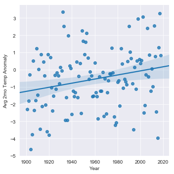

```python
sns.lmplot(x='Year', y='Avg 2mo Temp Anomaly', data=df);
```

Below is the same data without the trendline and color-coded based on whether or not the groundhog saw his shadow. At first glance, it doesn't look too good for the groundhog and his fortune-telling skills...

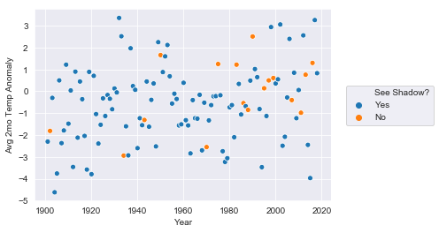

```python
ax = sns.scatterplot(x='Year', y='Avg 2mo Temp Anomaly', hue='See Shadow?', data=df);
ax.legend(loc='center', bbox_to_anchor=(1.2,0.5));
```

Here is another look at the data without the noise from the years. We would expect the blue points where he sees his shadow to be below 0 on the y-axis and the orange points where he doesn't see his shadow to be above 0 on the y-axis.

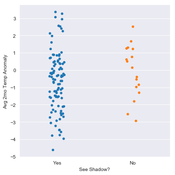

```python
sns.catplot(x="See Shadow?", y="Avg 2mo Temp Anomaly", data=df);
```

But remember that trendline that we saw initially? Let's take care of that and have another look.

```python
from sklearn.linear_model import LinearRegression
import numpy as np

linreg = LinearRegression();
linreg.fit(np.asarray(df['Year']).reshape(-1,1), np.asarray(df['Avg 2mo Temp Anomaly']).reshape(-1,1));
```

```python
y_pred = linreg.predict(np.asarray(df['Year']).reshape(-1,1))
```

```python
df['Expected Value'] = y_pred
```

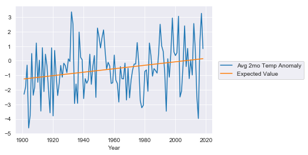

```python
ax = df.plot(x='Year');
ax.legend(loc='center', bbox_to_anchor=(1.25,0.5));
```

```python
df['Temp Anomaly'] = df['Avg 2mo Temp Anomaly'] - df['Expected Value']
```

```python
df['Avg Temp Trendline'] = 0
```

I have subtracted each value from its expected value based on the regression above. This effectively gives the data a mean of zero and allows us to compare a summer/winter temperature from 1901 to the summer/winter temperature in 2018. Check it out.

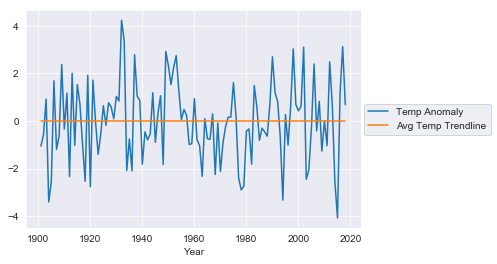

```python
#ax = df.plot(x='Year', y='Seasonal Line', color='orange')
ax = df[['Year', 'Temp Anomaly', 'Avg Temp Trendline']].plot(x='Year');
ax.legend(loc='center', bbox_to_anchor=(1.2,0.5));
```

```python
def is_winter(x):
    if x > 0:
        return 'No'
    else:
        return 'Yes'
```

```python
df['Is Winter?'] = df['Temp Anomaly'].apply(is_winter)
```

```python
df_cm = pd.crosstab(df['Is Winter?'], df['See Shadow?'], rownames=['Actual Winter'], colnames=['Predicted Winter'], margins=True)
```

```python
df['Temp Anomaly'] = df['Temp Anomaly'].astype(float)
```

Here are the same two graphs but with the transformed data.

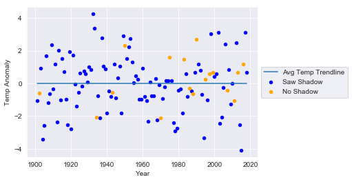

```python
ax = df[df['See Shadow?'] == 'Yes'].plot.scatter(x='Year', y='Temp Anomaly', color='blue', label='Saw Shadow');
df[df['See Shadow?'] == 'No'].plot.scatter(x='Year', y='Temp Anomaly', color='orange', label='No Shadow', ax=ax);
df.plot(x='Year', y='Avg Temp Trendline', ax=ax);
ax.legend(loc='center left', bbox_to_anchor=(1,0.5));
```

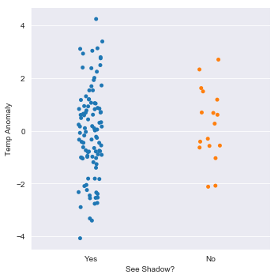

```python
sns.catplot(x="See Shadow?", y="Temp Anomaly", data=df);
```

Still not much better... But let's take a look at the numbers. In the matrix below, the correct predictions are in the top-left and bottom-right corners, while the incorrect predictions are in the bottom-left and top-right corners.

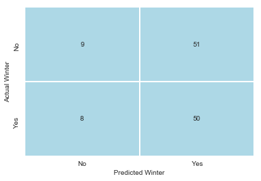

```python
from matplotlib.colors import ListedColormap

#sns.heatmap(df_cm.iloc[:-1,:-1], annot=True, cmap='terrain')
sns.heatmap(df_cm.iloc[:-1,:-1], annot=True, cmap=ListedColormap(['lightblue']), cbar=False, linewidths=1);
```

### What does this mean?

Well, when the groundhog does not see his shadow, he has correctly predicted the coming of spring 9/17 times, or 52.9% of the time.

When he sees his shadow, he correctly predicted more winter 50/101 times, or 49.5% of the time.

TL;DR ==> Don't take Punxsutawney Phil to Vegas and expect anything better than a coin-flip!

```python
from IPython.display import HTML

HTML('''<script>
code_show=true;
function code_toggle() {
 if (code_show){
 $('div.input').hide();
 } else {
 $('div.input').show();
 }
 code_show = !code_show
}
$( document ).ready(code_toggle);
</script>
<form action="javascript:code_toggle()"><input type="submit" value="Click here to toggle on/off the raw code."></form>''')
```